# London Fire Brigade Calls EDA - Analysis

Cem Gürkan - BDA 503 - Fall 2017

## Introduction

This is my first data analysis on R. Data is related with Calls made to London Fire Brigade between Jan 01 2017 to April 30 2017. Dataset is taken from [Kaggle|London Fire Data](https://www.kaggle.com/jboysen/london-fire/data).

I’ll do preliminary analysis on data and answer some questions and some visualizations.

Hope you enjoy :)

## Loading Data and Preliminary Analysis

Load libraries used for this study.

```r
# Load packages
library('ggplot2') # visualization
library('ggthemes') # visualization
library('dplyr') # data manipulation
library('scales') # visualization
```

Let’s import data set without header line.

```r
# Read the data and omit the first row
calls = read.csv("~/london_fire_brigade_service_calls.csv", header = TRUE)

# See the dimension of our data
dim(calls)
```

```
## [1] 32247    32
```

Our data consisting of 32 columns and 32247 rows. Let’s what are these columns and their contents

```r
# Structure and sample contents
glimpse(calls)
```

```
## Observations: 32,247
## Variables: 32
## $ ï..address_qualifier                       <fctr> Within same buildi...
## $ borough_code                               <fctr> E09000007, E090000...
## $ borough_name                               <fctr> CAMDEN, NEWHAM, WA...
## $ cal_year                                   <int> 2017, 2017, 2017, 2...
## $ date_of_call                               <fctr> 2017-01-20, 2017-0...
## $ easting_m                                  <int> 529459, NA, 536990,...
## $ easting_rounded                            <int> 529450, 539650, 536...
## $ first_pump_arriving_attendance_time        <int> 359, 211, NA, 295, ...
## $ first_pump_arriving_deployed_from_station  <fctr> Euston, Stratford,...
## $ frs                                        <fctr> London, London, Lo...
## $ hour_of_call                               <int> 8, 17, 18, 11, 17, ...
## $ incident_group                             <fctr> False Alarm, Speci...
## $ incident_number                            <fctr> 008148-20012017, 0...
```

[output cut: 19 more lines]

```r
# Summary of data
summary(calls)
```

```
##                                    ï..address_qualifier    borough_code
##  Correct incident location                   :19267     E09000033: 2469
##  Within same building                        : 5669     E09000007: 1500
##  In street outside gazetteer location        : 2592     E09000028: 1435
##  On land associated with building            : 2114     E09000022: 1383
##  In street close to gazetteer location       : 1128     E09000030: 1330
##  Open land/water - nearest gazetteer location:  866     E09000012: 1177
##  (Other)                                     :  611     (Other)  :22953
##         borough_name      cal_year        date_of_call     easting_m
##  WESTMINSTER  : 2469   Min.   :2017   2017-02-23:  525   Min.   :493654
##  CAMDEN       : 1500   1st Qu.:2017   2017-04-09:  346   1st Qu.:525061
##  SOUTHWARK    : 1435   Median :2017   2017-01-22:  335   Median :530716
##  LAMBETH      : 1383   Mean   :2017   2017-04-07:  329   Mean   :530668
##  TOWER HAMLETS: 1330   3rd Qu.:2017   2017-04-10:  317   3rd Qu.:536995
##  HACKNEY      : 1177   Max.   :2017   2017-04-15:  315   Max.   :560804
##  (Other)      :22953                  (Other)   :30080   NA's   :15411
##  easting_rounded  first_pump_arriving_attendance_time
##  Min.   :492450   Min.   :   2.0
##  1st Qu.:525150   1st Qu.: 232.0
##  Median :530850   Median : 298.0
##  Mean   :530641   Mean   : 318.2
##  3rd Qu.:536450   3rd Qu.: 379.0
##  Max.   :563150   Max.   :1196.0
##                   NA's   :1819
##  first_pump_arriving_deployed_from_station            frs
##                : 1819                      London       :32078
##  Soho          : 1205                      OverTheBorder:  169
##  Lambeth       :  641
##  Paddington    :  625
##  Euston        :  580
##  West Hampstead:  560
##  (Other)       :26817
##   hour_of_call           incident_group         incident_number
##  Min.   : 0.00   False Alarm    :15732   000003-01012017:    1
##  1st Qu.: 9.00   Fire           : 6434   000004-01012017:    1
##  Median :14.00   Special Service:10081   000005-01012017:    1
##  Mean   :13.47                           000006-01012017:    1
##  3rd Qu.:18.00                           000007-01012017:    1
##  Max.   :23.00                           000008-01012017:    1
##                                          (Other)        :32241
```

[output cut: 57 more lines]

```
##  18:03:40:    6   2017-01-10 20:54:46:    2   E05000649:  623
##  12:00:03:    5   2017-01-26 22:51:36:    2   E05000644:  490
##  16:32:40:    5   2017-02-05 13:51:44:    2   E05000138:  213
##  18:58:49:    5   2017-02-16 11:50:55:    2   E05000641:  209
##  19:21:23:    5   2017-03-01 20:43:29:    2   E05000367:  205
##  19:22:30:    5   2017-03-11 20:36:59:    2   E05000331:  203
##  (Other) :32216   (Other)            :32235   (Other)  :30304
##                      ward_name                       ward_name_new
##  WEST END                 :  623   WEST END                 :  623
##  ST. JAMES'S              :  490   ST. JAMES'S              :  490
##  FAIRFIELD                :  219   FAIRFIELD                :  219
##  HOLBORN AND COVENT GARDEN:  213   HOLBORN AND COVENT GARDEN:  213
##  MARYLEBONE HIGH STREET   :  209   MARYLEBONE HIGH STREET   :  209
##  BUNHILL                  :  205   BUNHILL                  :  205
##  (Other)                  :30288   (Other)                  :30288
```

## Data Exploration and Visualization

By creating trend analysis we can see number of calls on each day.

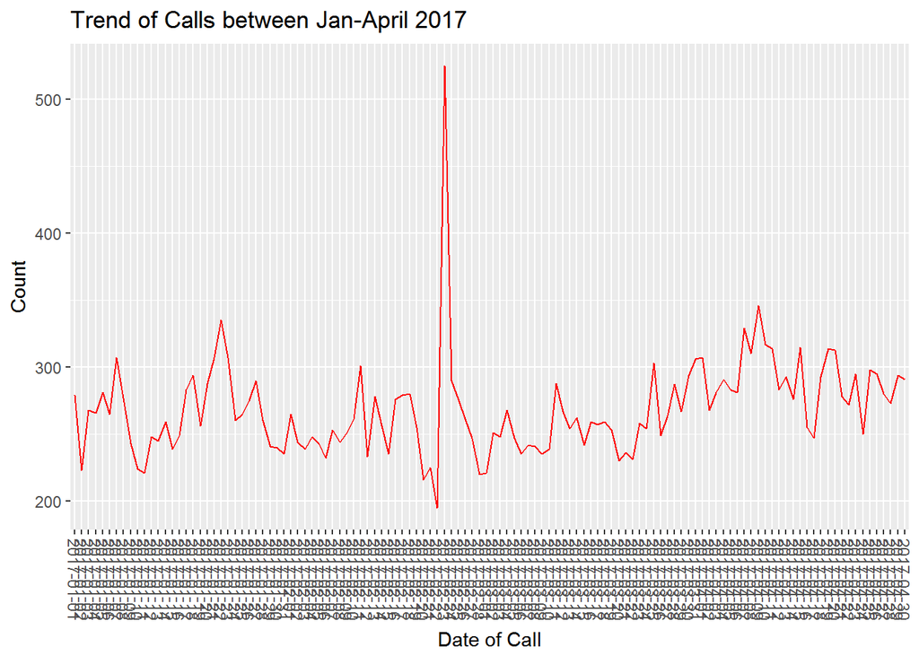

```r
# Find the numbers of call on each day.
grp_call <- calls %>%
  group_by(date_of_call) %>%
  summarise(count=n())

#Show on the graph, see the trends
ggplot(data=grp_call, aes(x=date_of_call, y=count, group = 1)) +
  geom_line(colour = "red") +
  labs(title="Trend of Calls between Jan-April 2017", x="Date of Call", y="Count") +
  theme (axis.text.x=element_text (angle=-90,vjust=0.5,hjust=0))
```

```r
#Average calls
grp_call %>% summarise(count=mean(count))
```

```
## # A tibble: 1 x 1
##     count
##     <dbl>
## 1 268.725
```

If we examine calls on day,

- The number of calls increases from 0500 and reaches its peak at 1800
- Early mornings have lower calls

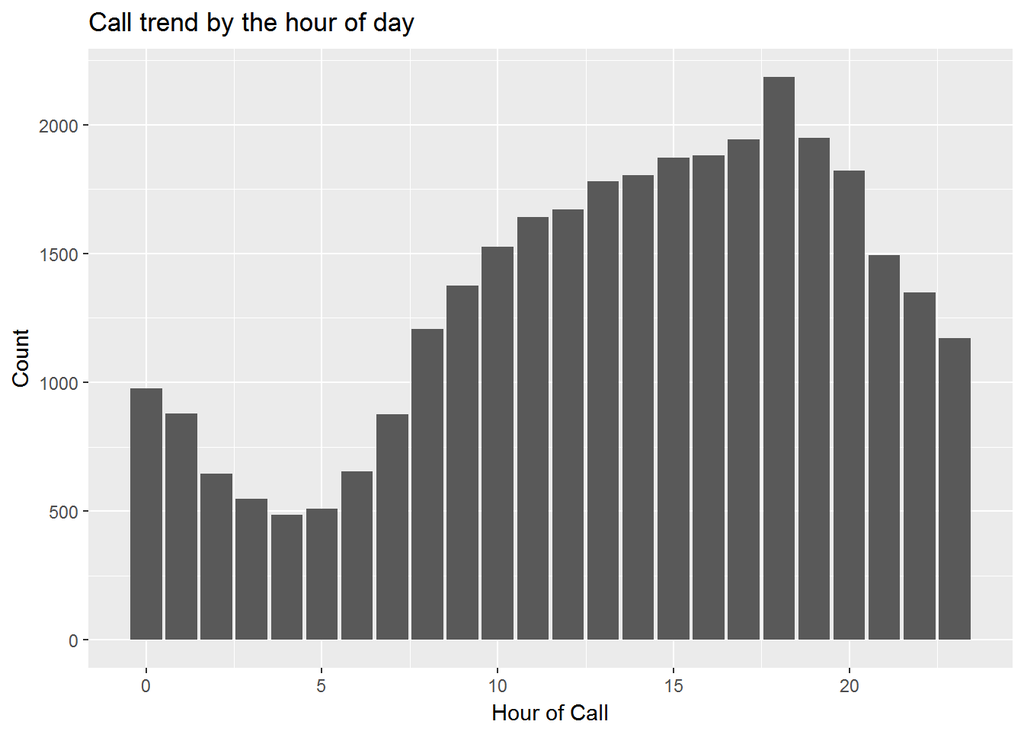

```r
ggplot(data=calls,aes(x=calls$hour_of_call, group=1)) +
geom_bar() +
labs(title="Call trend by the hour of day",x="Hour of Call",y="Count")
```

If we examine the response time;  
* Regardless of the hour of call, the average first response time is around 5 mins for all hours of the day

```r
data <- calls %>% mutate(first_pup_arriving_min=first_pump_arriving_attendance_time/60)
```

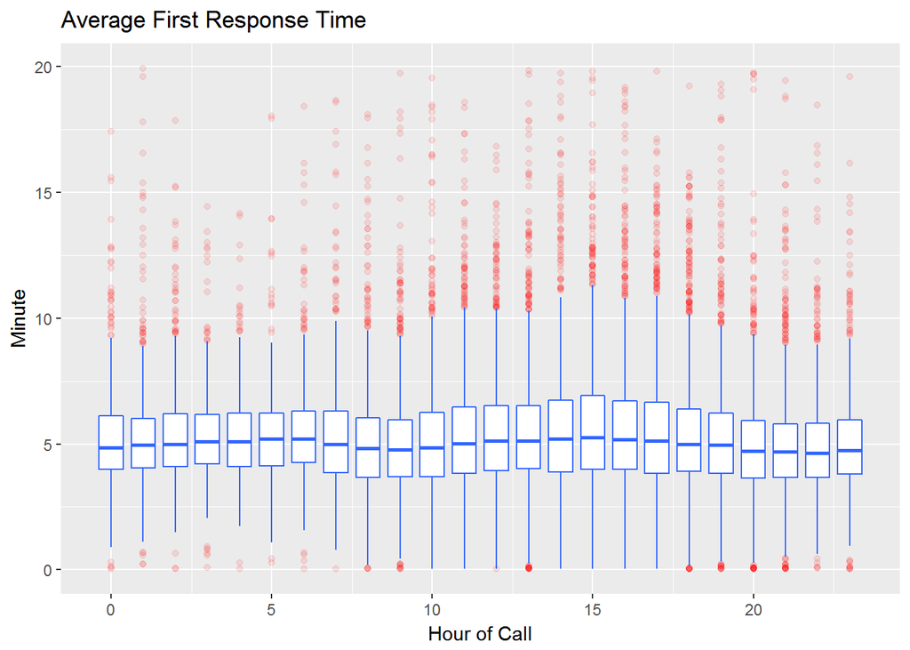

```r
ggplot(data=data,aes(y=data$first_pup_arriving_min, x=data$hour_of_call)) +
  geom_boxplot(aes(group = cut_width(hour_of_call, 0.5)), outlier.alpha = 0.1, outlier.colour = "red", colour = "#3366FF")+
labs(title="Average First Response Time",x="Hour of Call",y="Minute")
```

What about if we examine the highest calls day

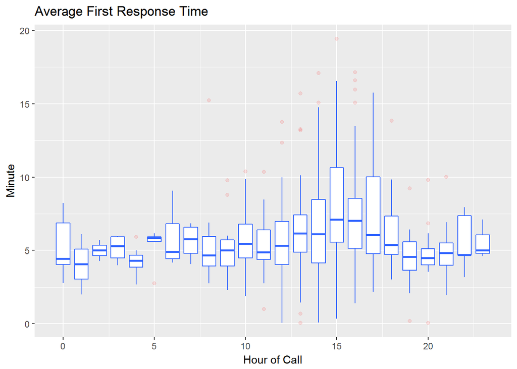

```r
#Highest call of the day
data <- calls %>% filter(date_of_call=="2017-02-23")
data <- data %>% mutate(first_pup_arriving_min=first_pump_arriving_attendance_time/60)


ggplot(data=data,aes(y=data$first_pup_arriving_min, x=data$hour_of_call)) +
  geom_boxplot(aes(group = cut_width(hour_of_call, 0.5)), outlier.alpha = 0.1, outlier.colour = "red", colour = "#3366FF")+
labs(title="Average First Response Time",x="Hour of Call",y="Minute")
```

If we want to look into which property type has most calls, Residential house is first one as expected.

```r
#Find the #of calls for each property category
data <- calls %>%
  group_by(property_category) %>%
  summarise(count=n())  %>%
  arrange(desc(count))

data
```

```
## # A tibble: 9 x 2
##   property_category count
##              <fctr> <int>
## 1          Dwelling 15240
## 2   Non Residential  7769
## 3      Road Vehicle  2777
## 4           Outdoor  2594
## 5 Outdoor Structure  2004
## 6 Other Residential  1796
## 7          Aircraft    25
## 8              Boat    24
## 9      Rail Vehicle    18
```

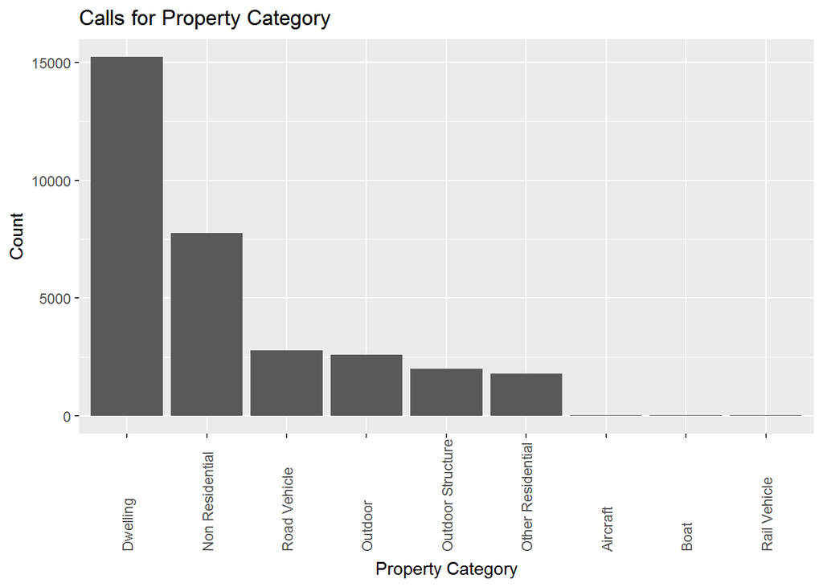

```r
ggplot(data=data,aes(x=reorder(property_category,-count), y=data$count)) +
  geom_bar(stat="identity") +
  labs(title="Calls for Property Category",x="Property Category",y="Count") +
  theme (axis.text.x=element_text (angle=90,vjust=0.5, hjust=0))
```